# Проект рекомендательной системы: фильмы

Турченко Федя, Нездоймышапко Мила, Гергенредер Костя, Макеев Артем

Группа 12

# Основные идеи

Проект позиционируется как проведение некого анализа для конкретного заказчика. В лице заказчика может выступать интернет-портал по рекомендациям фильмов, онлайн кинотеатры, а так же различные информационные источники с описаниями фильмов (к примеру, kinopoisk).

В основе создания рекомендательной системе - простота и прозрачность работы. Мы поставили перед собой цель сделать простую, но качественную систему, принцип работы которой будет потянет простому пользователю, а результат рекомендации будет наилучшим.

Основная идея рекомендации - предложение фильмов на основе “житейского опыта”. Поэтому для рекомендации мы используем то, на что обычно обращаем внимание при выборе фильма, а именно жанр, топ-3 актера, главный режиссер, ключевые слова.

# Содержание отчета:

### I. Первичный анализ данных

### II. Анализ сетевых данных и их интерпретация

### III. Анализ текстовых данных и их интерпретация

### IV. Построение рекомендательных систем - content-based

### V. Построение рекомендательных систем - коллаборативная фильтрация

### VI. Ответы на вопросы и комментарии, полученные в отзывах

### Дополнение: Краткое описание предложенных примеров для проверки системы.

# I. Первичный анализ данных

### В данном разделе мы подробнее разберём данные для проекта, проанилизируем, от чего может зависеть средняя оценка фильма.

Проверим, есть ли зависимость между среднеми оценками для жанров.В некоторых жанрах недостаточно наблюдений для проведения статистических тестов, а также данные по жанрам распределены неравномерно, что не даёт нам возможности использовать ANOVA. Однако мы можем использовать непараметрический аналог, например, Kruskall-Wallis для проверки зависимости, так как он не требует для себя никаких предположений.

$H_0$: - Разницы между средним значение для жанров нет

$H_A$: - Разница в средним значение для жанров есть

```
##
##  Kruskal-Wallis rank sum test
##
## data:  movies_with_genres1$vote_average by movies_with_genres1$genres_sep
## Kruskal-Wallis chi-squared = 46.565, df = 19, p-value = 0.0004121
```

Как видно из итогов теста, p-value меньше чем 0.05, что даёт нам возможность отрицать нулевую гипотезу. Таким образом, среднее значение оценки отличается для жанров. Таким образом, средняя оценка для фильма может зависеть от жанра, поскольку они отличаются для разных категорий жанров. То есть жанр является важной характеристикой для определения того, какая средняя оценка стоит у фильма и для того чтобы рекомедовать людям фильмы.

**Корелляция**

Теперь посмотрим на корреляцию средней оценки с различными численными переменными. Будем использовать метод Kendall, поскольку для большинства переменных распределение не нормальное. Итогом корреляционного анализа была выявлена наиболее сильная связь.

Проверим есть ли зависимость между оценкой популярности фильма и его среднюю оценку.

```
##
##  Kendall's rank correlation tau
##
## data:  movies12$popularity and movies12$vote_average
## z = 7.6132, p-value = 2.674e-14
## alternative hypothesis: true tau is not equal to 0
## sample estimates:
##       tau
## 0.2345387
```

Зависимость между популярностью фильмы и его средней оценкой существует, чем больше популярность фильма, тем выше его оценка. Тем не менее она очень слабая, так как коэффициент равен 0,23. Результат статистически значим. Однако в рекомендации мы тем не менее можем полагаться на популярность фильма, как на переменную способную подобрать наиболее значимые фильмы (как, например, в сетевом анализе)

Проверим есть ли зависимость средней оценки с количеством оценок.

```
##
##  Kendall's rank correlation tau
##
## data:  movies12$vote_count and movies12$vote_average
## z = 8.8993, p-value < 2.2e-16
## alternative hypothesis: true tau is not equal to 0
## sample estimates:
##       tau
## 0.2745671
```

Достаточно логично, количество проголосовавших влияет на среднюю оценку фильма. Корреляция всё ещё слабая, потому что коэффициент равен 0,27. Она положительная, то есть чем больше у фильма оценок, тем выше может быть его средняя оценка. Результат статистически значим, p-value меньше 0.05. В системах мы будем отбирать фильмы, у которых будет больше определенного количества оценок, чтобы результат был более надёжным, а оценка фильма не была занижена из-за отсутствия оценок.

Проверим корреляцию между переменными, которые сильнее всего были связаны с средней оценкой, так как количество оценок фильма может зависет от его популярности.

```
##
##  Kendall's rank correlation tau
##
## data:  movies12$popularity and movies12$vote_count
## z = 23.703, p-value < 2.2e-16
## alternative hypothesis: true tau is not equal to 0
## sample estimates:
##       tau
## 0.7196877
```

Действительно, корреляция между количеством оценок и его популярностью очень сильная, коэффициент равен 0.72. Результат статистически значим, так как p-value меньше 0.05.

# II. Анализ сетевых данных и их интерпретация

### В данном разделе мы ознакомимся с результатами сетевого анализа данных и проинтепретируем их.

Делаем проекцию, где связь между фильмами будет отображать наличие общего жанра.

```
## IGRAPH 29390dd UNW- 484 60447 --
## + attr: name (v/c), weight (e/n)
## + edges from 29390dd (vertex names):
##  [1] id_2--id_3   id_2--id_16  id_2--id_19  id_2--id_25  id_2--id_69
##  [6] id_2--id_70  id_2--id_104 id_2--id_110 id_2--id_111 id_2--id_112
## [11] id_2--id_140 id_2--id_141 id_2--id_145 id_2--id_150 id_2--id_153
## [16] id_2--id_173 id_2--id_185 id_2--id_186 id_2--id_203 id_2--id_216
## [21] id_2--id_223 id_2--id_224 id_2--id_225 id_2--id_231 id_2--id_232
## [26] id_2--id_235 id_2--id_236 id_2--id_237 id_2--id_246 id_2--id_247
## [31] id_2--id_256 id_2--id_261 id_2--id_265 id_2--id_266 id_2--id_273
## [36] id_2--id_293 id_2--id_300 id_2--id_303 id_2--id_307 id_2--id_316
## + ... omitted several edges
```

Будем использовать взвешенную проекцию, которая будет взвешивать силу связи между фильмами на популярность жанра. Связь между непопулярными жанрами будет сильнее. Взвешиваем и строим распределение силы связи между фильмами с указанием среднего. Также сохраняем в отдельный датасет соответствие id фильма и порядковый номер.

Создадим взвешенную проекцию. i и j в данном случае являются связью между фильмами, w - весом связи.

```
##   i  j           w
## 1 1  2 0.003623188
## 2 1  3 0.011111111
## 3 1  4 0.011111111
## 4 1  6 0.014734300
## 5 1  9 0.003623188
## 6 1 12 0.011111111
```

Удалим свзяи у которых сила ниже 0.02 и сделаем более сильную фильтрацию, разобъём фильмы на сообщества.

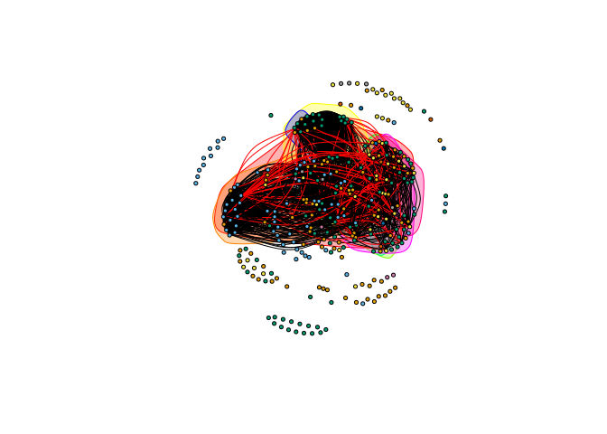

В целом сообщества в данном случае отображают фильмы, которые относятся к похожим жанрам. Как видно из графа, у нас всё равно остаются фильмы, которые не связаны между собой и находятся вне сообществ. Возможно, эти фильмы отличаются по жанрам от большинства оставшихся фильмов, относятся к нераспространённому жанру.

Теперь зная понравившиеся пользователю фильмы, можем предлагать ему фильмы из данного сообщества. Допустим нашему пользователю нравится фильм “Star Trek V: The Final Frontier”.

Определяем сообщество фильма и выводим фильмы данного сообщества, отсортированные по популярности.

```
## # A tibble: 4 x 5
##   movieId title            popularity genres                          group
##     <dbl> <chr>                 <dbl> <chr>                           <dbl>
## 1     435 The Day After T…      15.0  "[{\"id\": 28, \"name\": \"Act…    10
## 2      95 Armageddon            13.2  "[{\"id\": 28, \"name\": \"Act…    10
## 3     172 Star Trek V: Th…      12.3  "[{\"id\": 878, \"name\": \"Sc…    10
## 4    2080 X-Men Origins: …       1.46 "[{\"id\": 12, \"name\": \"Adv…    10
```

Как видно из полученной таблицы, в одном сообществе находятся похожие фильмы по жанру. В данном случае жанр играет значимую роль, поскольку можно заметить, что не только жанр совпадает, но и фильмы в целом являются похожими на фильм, который нравится нашему пользователю. Также в сообществе есть как популярные фильмы, так и не очень, что означает, что даже если пользователь уже видел фильмы, которые более популярны его любимого фильма, то он также может посмотреть менее популярные фильмы, но похожие на понравившийся ему.

B целом можно сказать, что жанр является важной характеристикой для того чтобы рекомендовать людям фильмы, однако сам сетевой анализ в рекомендательных системах мы использовать не будем.

# III. Анализ текстовых данных и их интерпретация

### В данном разделе мы ознакомимся с результатами текстового анализа данных и проинтепретируем их.

**Семантический анализ**

Идея заключалась в том, чтобы проверить корреляцию между эмоциональностью описаний (установленную по семантическому анализу) и оценкой фильма. Логика тут состояла в том, что, теоретически, более эмоционально яркие описания к фильмам могут быть у более качественных картин в принципе.

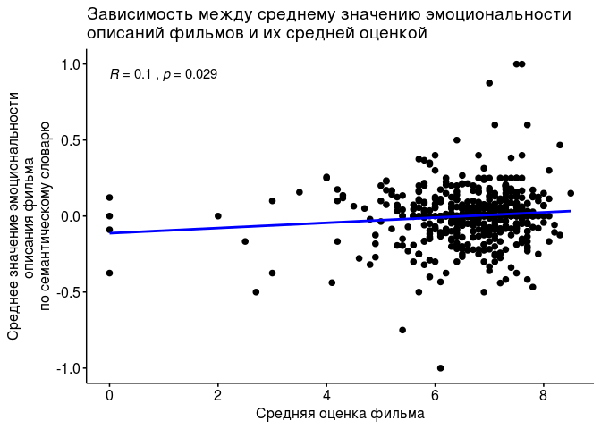

# IV. Построение рекомендательных систем - content-based

### Построение рекомендательной системы по признакам (content-based)

В качестве признаков были использованы жанр, топ-3 актера, главный режиссер, ключевые слова. Именно такие переменные были отобраны, исходя из common sense. Думаю, что большинство людей при выборе себе фильма на просмотр так или иначе, но обращают в первую очередь внимание именно на эти признаки, поскольку они являются “лицом” фильма.

**Функция Content-based**

На вход принимает названия фильмов, которые пользователь посмотрел (больше одного), а также количество фильмов, которые он хочет получить в рекомендацию (от четырех, поскольку первые три фильма, которые выводятся - те же, что и введены пользователем; в shiny эта проблема нивелирована).

```r
for_system = movies_cbs %>% select(title, movieId)
RecommendFilm = function(film, user_n){
            searched = for_system %>% filter(title %in% film)
            if (nrow(searched)==0) {
                recommend = "The Lord of The Ring"
            } else{
                mostSimilar = head(sort(sim[,as.character(searched$movieId)], decreasing = T), n = user_n)
                a = which(sim[,as.character(searched$movieId)] %in% mostSimilar, arr.ind = TRUE)
                index = arrayInd(a, .dim = dim(sim[,as.character(searched$movieId)]))
                result = rownames(sim)[index[,1]]
                mostSimilar_2 = data.frame(movieId = as.numeric(result),
                                           similar = sim[,as.character(searched$movieId)][index])
                recommend = mostSimilar_2 %>% left_join(for_system) %>% select(movieId, title, similar) %>% arrange(-similar) %>% unique()
            }
            recommend
        }
```

Пример рекомендации:

```r
RecommendFilm(film = c("Casino", "Four Rooms", "Disclosure"), user_n = 6)
```

```
##   movieId                title   similar
## 1     524               Casino 1.0000000
## 2       5           Four Rooms 1.0000000
## 3    8984           Disclosure 1.0000000
## 4   33166       Downhill Racer 0.9999999
## 5    8665 K-19: The Widowmaker 0.9999999
## 6   49530              In Time 0.9999999
```

**Q: Что должен ввести пользователь в content based?**

A: Пользователю достаточно выбрать фильмы из предложенного списка, которые ему нравятся. На выходе он получит рекомендации фильмов в количестве от 1 до 3 штук.

**Shiny**

> Ссылка на приложение: [Shiny on Google Drive](https://drive.google.com/drive/folders/1i7Nqjpgoo8sym6t_nfMNqktCwNgCqVtA?usp=sharing) Ссылка на веб версию: https://bit.ly/2LYUTyA

**Внутренняя пользовательская оценка для content-based системы**

Вводными данными в данном случае являются любимые фильмы пользователя, рекомендация будет предоставлять до 3х фильмов, наиболее похожим по характеристикам на любимые фильмы пользователя.

Предположим, нашему пользователю нравятся боевики, такие как “Rush Hour”, “Armageddon” и “The Getaway”.

Если бы мы были пользователем, мы бы ожидали, что наша система будет предлагать нам также боевики и близкие по жанру фильмы (триллер/приключения), приблизительно этого же времени (90-е), в создании которых могли учавствовать одни и те же люди.

# V. Построение рекомендательных систем - коллаборативная фильтрация

### Построение рекомендательной системы по оценкам пользователей

Коллаборативная фильтрация - это один из методов построения рекомендаций, использующий известные предпочтения (оценки) группы пользователей для прогнозирования неизвестных предпочтений другого пользователя.

**Система IBCF**

Построим также модель, основанную на схожести самих фильмов, методом IBCF и проверим её качество. Как видно из метрик качества, ошибки для данной модели гораздо больше чем для модели, основанной на схожести оценок пользователей. Таким образом, модель UBCF лучше, а потому для рекомендации мы будем использовать её.

```
## Recommender of type 'IBCF' for 'realRatingMatrix'
## learned using 124 users.
```

```
## Recommendations as 'topNList' with n = 6 for 30 users.
```

|  | RMSE | MSE | MAE |
| --- | --- | --- | --- |
| eval_ubcf | 0.9082547 | 0.8249266 | 0.6989417 |
| eval_ibcf | 1.2720564 | 1.6181275 | 0.8958041 |

Дополнительно сравним системы UBCF и IBCF, чтобы достоверно убедиться в выборе лучшей системы. Для это создадим матрицу ошибок перекрёстной проверки для каждой системы.

```
## IBCF run fold/sample [model time/prediction time]
##   1  [0.352sec/0.028sec]
```

|  | TP | FP | FN | TN | precision | recall | TPR | FPR |
| --- | --- | --- | --- | --- | --- | --- | --- | --- |
| 10 | 0.7419355 | 9.258064 | 17.61290 | 284.3871 | 0.0741935 | 0.0488428 | 0.0488428 | 0.0315521 |
| 20 | 1.4516129 | 18.548387 | 16.90323 | 275.0968 | 0.0725806 | 0.0724554 | 0.0724554 | 0.0630958 |
| 30 | 1.8387097 | 28.161290 | 16.51613 | 265.4839 | 0.0612903 | 0.0960381 | 0.0960381 | 0.0958973 |
| 40 | 2.1612903 | 37.838710 | 16.19355 | 255.8065 | 0.0540323 | 0.1240293 | 0.1240293 | 0.1289367 |
| 50 | 2.5483871 | 47.451613 | 15.80645 | 246.1935 | 0.0509677 | 0.1465435 | 0.1465435 | 0.1617310 |
| 60 | 3.0322581 | 56.774194 | 15.32258 | 236.8710 | 0.0505376 | 0.1754138 | 0.1754138 | 0.1934877 |

```
## UBCF run fold/sample [model time/prediction time]
##   1  [0.08sec/0.068sec]
```

|  | TP | FP | FN | TN | precision | recall | TPR | FPR |
| --- | --- | --- | --- | --- | --- | --- | --- | --- |
| 10 | 1.903226 | 8.096774 | 16.45161 | 285.5484 | 0.1903226 | 0.1286932 | 0.1286932 | 0.0275032 |
| 20 | 2.806452 | 17.193548 | 15.54839 | 276.4516 | 0.1403226 | 0.1861723 | 0.1861723 | 0.0584232 |
| 30 | 3.645161 | 26.354839 | 14.70968 | 267.2903 | 0.1215054 | 0.2386210 | 0.2386210 | 0.0895527 |
| 40 | 4.354839 | 35.645161 | 14.00000 | 258.0000 | 0.1088710 | 0.2629950 | 0.2629950 | 0.1211387 |
| 50 | 5.225807 | 44.774194 | 13.12903 | 248.8710 | 0.1045161 | 0.3444668 | 0.3444668 | 0.1522216 |
| 60 | 5.967742 | 54.032258 | 12.38710 | 239.6129 | 0.0994624 | 0.3806406 | 0.3806406 | 0.1837063 |

```
## IBCF run fold/sample [model time/prediction time]
##   1  [0.236sec/0.032sec]
## UBCF run fold/sample [model time/prediction time]
##   1  [0.004sec/0.068sec]
```

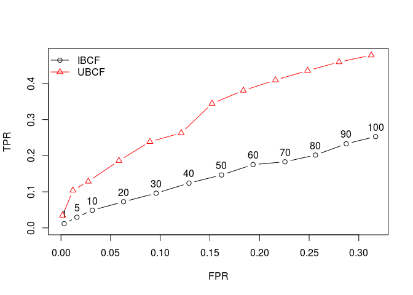

Из кривых ошибок ROC для систем видно, что модель UBCF работает лучше, так как TPR - уровень истинно-положительного решения опять таки выше для UBCF системы, что показывает, что она делает лучшие предсказания.

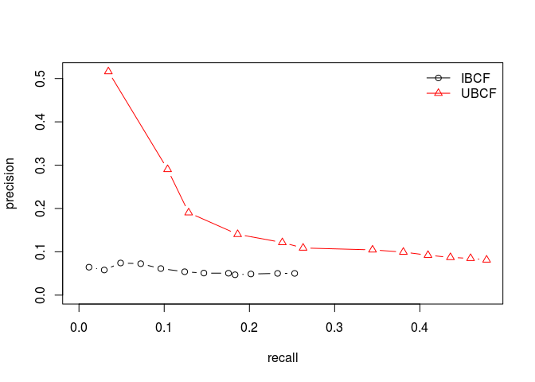

График точности и отзывчивости также подтверждает, релевантность выше для UBCF, так как доля схожих, релевантных фильмов среди предсказанных и от общего количества релевантных фильмов выше для этой системы. Данный анализ показывает, что UBCF система гораздо лучше IBCF предсказывает фильмы, а потому в анализе мы будем использовать именно её.

**Функция коллаборативной фильтрации**

Оформим рекомендательную систему в виде функции. Всего у нас есть рекомендации для 30 пользователей. То есть в функцию можно подставлять любого пользователя от 1 до 30 как входной аргумент, после чего для введённого номера пользователя мы получим значение функции - рекомендации для этого пользователя (6 фильмов).

```r
getFilms = function(i){
recc_user <- recc_predicted@items[[i]]
movies_user <- recc_predicted@itemLabels[recc_user]
names_movies_user<- movies12$title[match(movies_user, movies12$movieId)]
names_movies_user
}
```

Проверим для 30го пользователя:

```
## [1] "Jarhead"                 "Gleaming the Cube"
## [3] "2001: A Space Odyssey"   "The Hidden Fortress"
## [5] "Speed 2: Cruise Control" "Arlington Road"
```

**Проверим качество модели на конкретных примерах**

Проверим рекомендацию для пользователя с номером id 44958. Сперва посмотрим, какие фильмы понравились пользователю. Отберём фильмы с оценкой 5.

```
##  [1]   296   318   593   858  1213  2324  4226  4235  4993  5618  6016
## [12] 33166 44191 48780
```

```
##                                                      title movieId
## 1                                                     Boat   48780
## 2                                              Local Color    2324
## 3                                             Loose Screws   44191
## 4 Shriek If You Know What I Did Last Friday the Thirteenth    4226
## 5                                           Downhill Racer   33166
## 6                                        The Sicilian Clan    4235
##   genres_sep
## 1    Foreign
## 2      Drama
## 3     Comedy
## 4     Comedy
## 5      Drama
## 6      Crime
```

Теперь посмотрим, какую часть занимает каждый жанр среди этих фильмов, посчитав пропорцию. Выше всего пользователь оценивает фильмы, относящиеся к жанрам драмы и триллера. Таким образом, мы будем ожидать, что система будет рекомендовать нам фильмы похожих жанров.

```
## # A tibble: 11 x 3
##    genres_sep          n   prop
##    <fct>           <int>  <dbl>
##  1 Drama               7 0.241
##  2 Thriller            5 0.172
##  3 Comedy              4 0.138
##  4 Crime               3 0.103
##  5 Action              2 0.0690
##  6 Science Fiction     2 0.0690
##  7 Romance             2 0.0690
##  8 Foreign             1 0.0345
##  9 Adventure           1 0.0345
## 10 Western             1 0.0345
## 11 Mystery             1 0.0345
```

Эти фильмы порекомендовала пользователю система.

```
## [1] "Ocean's Eleven"      "Sissi"               "Broken Blossoms"
## [4] "The Sixth Sense"     "Jarhead"             "Million Dollar Baby"
```

Если посмотреть на предсказанные оценки, то несмотря на то, что в целом пользователь оценил бы их ниже чем максимум, все они всё равно достаточно высокие.

```
## [1] 4.386066 4.347337 4.333135 4.328850 4.303569 4.296130
```

Проверим, есть ли реальные оценки у этих фильмов. К сожалению, их нет.

```
## # A tibble: 0 x 3
## # … with 3 variables: userId <dbl>, movieId <dbl>, rating <dbl>
```

Теперь посмотрим на жанры предсказанных фильмов. В целом можно заметить, что в большинстве жанры предложенных фильмов совпадают с теми жанрами, которые высоко оценил пользователь. Это означает, что система работает хорошо, поскольку она предлагает фильмы, близкие к тем, которые пользователь оценил выше всего.

```
## # A tibble: 7 x 3
##   genres_sep     n   prop
##   <fct>      <int>  <dbl>
## 1 Drama          5 0.385
## 2 Thriller       2 0.154
## 3 Romance        2 0.154
## 4 Comedy         1 0.0769
## 5 Crime          1 0.0769
## 6 War            1 0.0769
## 7 Mystery        1 0.0769
```

Проверим также, совпадают ли высоко оцененные пользователем страны-производители с тем, фильмы каких стран им предлагает система. Отбираем страны фильмов, оцененных на 5.

```
##  [1]   296   318   593   858  1213  2324  4226  4235  4993  5618  6016
## [12] 33166 44191 48780
```

```
##                                                      title movieId
## 1                                                     Boat   48780
## 2                                              Local Color    2324
## 3                                             Loose Screws   44191
## 4 Shriek If You Know What I Did Last Friday the Thirteenth    4226
## 5                                           Downhill Racer   33166
## 6                                        The Sicilian Clan    4235
##   production_countries_sep
## 1 United States of America
## 2 United States of America
## 3                   Canada
## 4 United States of America
## 5 United States of America
## 6                   France
```

Посмотрим, сколько среди них каких стран. Особенно нашему пользователю нравятся фильмы из США. Если мы были пользователем, мы бы ожидали, что предложенные фильмы также могут быть из этой страны.

```
## # A tibble: 7 x 3
##   production_countries_sep     n  prop
##   <fct>                    <int> <dbl>
## 1 United States of America     9  0.45
## 2 France                       3  0.15
## 3 United Kingdom               2  0.1
## 4 Germany                      2  0.1
## 5 Canada                       2  0.1
## 6 Ireland                      1  0.05
## 7 Russia                       1  0.05
```

Теперь посмотрим на страны предсказанных фильмов. Самую большую часть составляет США, то есть это предсказание совпадает с тем, какие фильмы нравятся пользователю. Мы ещё раз убедились, что система работает исправно.

```
## # A tibble: 3 x 3
##   production_countries_sep     n  prop
##   <fct>                    <int> <dbl>
## 1 United States of America     5 0.714
## 2 Germany                      1 0.143
## 3 Austria                      1 0.143
```

**Q: Что должен ввести пользователь в системе с коллаборативной фильтрацией?**

A: Пользователю достаточно зарегестрироваться и оценить предложенный список фильмов от 1 до 5 баллов, для того, чтобы он появился в базе данных как определенный ID. На основании этого мы строим рекомендацию.

# VI. Ответы на вопросы и комментарии, полученные в отзывах

### Ответы на вопросы и рекомендации в формате Q&A, полученные во время peer-review

> Q1: Будет ли функция, лежащая в основе приложения, работать, не выдавая ошибку, если входные данные не были введены (то есть в условиях “очень” холодного старта)? Какие фильмы будут рекомендованы в таком случае?

A: Функция работать не будет. Обязательно нужно ввести более одного просмотренного фильма, иначе выдаст ошибку. Не очень понятно, правда, как можно получить рекомендацию по признакам, если вообще не вводить ничего.

> Q2: Откуда были взяты дополнительные данные об актёрах и режиссёрах? Как отбирались топ-3 актёра и главный режиссёр для content-based рекомендательной системы?

A: Дополнительные данные были взяты с Kaggle. Топ-3 актера – первые 3 в списке, режиссер – первый в списке.

> Q3: Как создавалась выборка при проведении опроса для оценки content-based рекомендательной системы?

A: Люди, которые протестировали приложение, переходили в Гугл Форму, заполняли ее.

> Q4: Вы сказали, что для рекомендательных систем вы использовали описание фильмов. Но я не понял, как описание влияет на выдаваемые рекомендации? Может быть я просто что-то не понял….

A: Были взяты не сами описания, а ключевые слова. Это было сделано для того, чтобы создать дополнительный критерий схожести к жанрам. То есть мы можем рекомендовать хорроры, как схожие фильмы, но будет лучше, если у этих хорроров еще и часть ключевых слов совпадет – значит фильмы плюс-минус об одном и том же.

> Q5: Не очень понятно, каким образом ребята дадут пользователю не из системы возможность оценить фильмы (непонятно из презентации реализовано это, или это существует только на уровне идеи).

A: Для того, чтобы получить рекомендацию по content-based системе, достаточно просто открыть shiny-приложение и ввести необходимый инпут. Для этого не обязательно быть где-либо зарегистрированным.

> Q6: Характеристики, выбранные для построения матриц объяснены, но сомнения вызывает эмоциональность описаний, так как мы пришли подобном анализе нашли эту характеристику нерелевантной, так как корреляция действительно мала, а статистически значимая каузация отсутствует.

A: Эмоциональность описаний мы также отбросили – для content-based системы эта переменная не использовалась, что указано на слайдах презентации.

> Q7: Как ребята работали с жанрами, так как в примерах, которые они показывали, слишком маленькое количество жанров, и много повторяющихся, что указывает либо на то, что пример состоял из похожих фильмов (что не даёт оценить работу системы при разнообразных вкусах пользователя), либо, что жанры были сокращены (что может создать неправильное представление о фильме, например, мультфильм “Каролина” будет казаться только мультфильмом, а не мультфильмом-страшилкой)

A: Не понятен смысл вопроса. Система будет работать на любых данных, мы же делали только на нашем небольшом наборе фильмов.

> Q8: Что делать пользователю, если он не хочет быть внесен в базу данных сайта, но все равно хочет, чтобы ему порекомендовали фильмы? Что будет предложено пользователю, если получилось, что фильмы, которые система порекомендовала новому пользователю, уже просмотрены им?

A: Для получения рекомендации не нужно быть зарегестрированным в системе, достаточно перейти в шайни приложение и отметить те фильмы, которые пользователю нравятся. Соответственно, если происходит рекомендация уже просмотренных фильмов, это можно решить с помощью 1) регистрации и ведения базы данных просмотренных фильмов, 2) добавлением кнопки ПРОСМОТРЕННО возле рекомендованного фильма и добавление в список фильма, который подходит по совпадению, но не был показан из-за ограничения количества выданных в таблице фильмов.

> Q9: Я не увидел анализ сетей (картиночку хотя бы), почему только 3 фильма предлагаются, хотелось бы больше.

A: Анализ сетей представлен в отчете, а также в коде R. 3 фильма выбрано для выдачи наиболее подходящих фильмов (т.к. они ранжированны по коэф. схожести). Это количество наиболее оптимальное.

> Q10: В начале презентации было сказано, что участники проектной группы поставили себя на место пользователя и подходили к вопросу “с бытовой точки зрения”. Поэтому хотелось бы, чтобы в презентации не только была показана рекомендация и формальная схожесть с фильмами, на которых она основана (по шайни), но и была бы дана “человеческая” оценка ей. Насколько точной получилась рекомендация по мнению создателей шайни; в чем схожи фильмы тематически; как соотносятся, например, жанры у порекомендованных фильмов и фильмов, по которым рекомендовали?

A: Оценка обоих систем приведена в отчете.

> Q11: 1) Почему вы провели сетевой анализ только по жанрам? 2) Как вы использовали текстовый анализ в рекомендательных системах?

A: 1) В результате разведочного анализа переменных, между жанром и средней оценкой фильма была установлена зависимость, поэтому данная переменная была учтена как важная для рекомендации. Сети также были построены по другим переменным (таким как страна производитель, и компания производитель), однако они работали схожим принципом с сетями по жанрам. Сети по жанрам работали из них наилучшем образом и были оставлены в финальном результате. 2) В отчете указано, что результаты текстового анализа использоваться не будут.

> Q12: Не совсем понятно, почему для коллаборативной фильтрации используется схожесть по жанрам, а не по оценкам. Характеристики ведь используются для content-based рекомендации.

A: Характеристики фильмов были использованы для оценки коллаборативной фильтрации, чтобы проверить, насколько предложенные фильмы совпадают с теми, которые пользователь высоко оценил. Так как у пользователя отсутствовали оценки предложенным фильмам, то данный метод хорошо помогает проверить схожесть предложенных и оцененных фильмов.

> Q13: Для проверки работы коллаборативной системы, основанной на рекомендациях по схожести оценок пользователей, использовались только наивысшие оценки у пользователя, хотя система предполагает поиск других пользователей со схожими оценками. То есть логично было бы рассматривать все оценки.

A: Мы исходили из принципа - оценил лучше, больше понравился. Мы считаем этот подход наиболее подходящим для проекта нашего уровня.

> Q14: Не совсем поняла, что значит на базе житейского опыта.

A: Для рекомендации мы используем то, на что обычно обращаем внимание при выборе фильма, а именно жанр, топ-3 актера, главный режиссер, ключевые слова. То есть, простота системы объясняется алгоритмом подбора себе фильмов среднестатистическим пользователем.

> Q15: 1) Мне кажется не совсем оправданным использование семибалльной шкалы оценок, так как, во-первых, это сложнее сопоставить с оценками работы рекомендательной системы на основе данных, во-вторых, это все же не интуитивно понятная для пользователя шкала 2) Проблема с франшизами (подробнее описано в следующем пункте) 3) Вы сравнили методы (IBCF и UBCF) только на основе уже имеющихся данных, почему бы не попросить и пользователей поставить оценки тем фильмам, которые они смотрели (тем более, что вы предлагаете всего три, так что это не будет слишком сложным) и так же сравнить эти два метода 4) Также мне кажется, что пользователю сложно оценить рекомендованные фильмы только по названию, поэтому можно было бы добавить описание к каждому рекомендованному фильму

A: 1) Семибальная система гугл формы была использована для того, чтобы пользователи не могли оценить работу оценкой “ну норм”, то есть количество нечетное без средних оценок. Было принято решение, что семибальная система наиболее классическая и считается наиболее оптимальной. 2) Проблема с франшизами была решена на момент выпуска презентации, что и было упомянуто по ходу описания. 3) Методология нашего проекта допускает использование внутренней оценки для проверки адекватности рекомендации, однако, проверять каждый набор фильмов для сопоставления ошибок двух подходов не считаем обоснованным. Мы строим на основе статистических данных и получаем адекватные рекомендации этим методом. 4) Столкнувшись с техническими трудностями, мы решили временно не добавлять описания к рекомендованным фильмам. Однако на качество рекомендации это не повлияло.

> Q16: Но в проблеме холодного старта в теории может быть возможен такой вариант, что новый пользователь не видел фильмов вообще/не помнит названий просмотренных фильмов/хочет получить рекомендации сразу. Что система может предложить в таком случае?

A: Проблема холодного старта в нашей системе решается оценкой стандартного списка фильмов для определения схожести. То есть, внесение в базу данных пользователя и его оценок. В случае, если пользователь ничего не хочет вводить, можно предложить пользователю те фильмы, которые нравятся всем (т.е. список фильмов с максимальным рейтингом).

> Q17: 1) больше информации про качество рекомендации content - based системы, насколько фильмы совпадают с тем, что введен пользователем 2) в content - based системе хотелось бы увидеть больше рекомендованных фильмов, чем три 3) неплохо было бы продемонстрировать пример с холодным стартом, как работает схема, описанная в видео, для нового пользователя

# Дополнение: Краткое описание предложенных примеров для проверки системы.

Основываясь на предложенных к нашей видеопрезентации примерах, мы решили проверить несколько из них. Сложность данной проверки состояла в том, что наш датасет ограниченный, а потому он не включал большое количество фильмов, по которым пользователи хотели бы сделать рекомендацию, или которые рекомендация могла бы выдать. **Однако напоминаем, что нами было разработано шайни приложение, позволяющее оценить это самостоятельно.**

Например, один из запросов был о том, будут ли порекомендованы фильмы с Хью Джекманом в главных ролях, если его указать в запросе. Однако в наших данных всего два фильма с Хью Джекманом – “Люди Икс: Начало. Росомаха” и “Фонтан”. По результатам запроса фильмы с этим актёром не рекомендуются, так как их просто нет в системе. При этом схожесть самих фильмов всё равно присутствует. Одним из вопросов в комментариях также был “Как работает система, если указать фильмы разных жанров? Будет ли результат скошен в сторону одного фильма?” Как видно из запроса, два фильма относятся к разным жанрам – супергеройский боевик и притча. Наша система порекомендовала фильмы “Достигая невозможного” (боевик, детектив), “Миссия на Марс” (фантастика, приключения, триллер), которые приближены по содержанию к “Люди Икс” и “Рокки Бальбоа” (спорт, драма), который, как и “Фонтан” повествует о ценностях в жизни. Таким образом, система работает хорошо, советует схожие фильмы, учитывает различные фильмы в запросе.

Несколько запросов на примеры интересовались тем, как работает наша система с франшизами. Например, если ввести первую часть “Звёздных Войн” и “Назад в будущее”, будет ли рекомендовано продолжение? Нет, не будет. Наша система, наоборот, избегает проблему с франшизами, так как если человеку нравится первая часть фильма, то он/а с большой вероятностью знает о продолжении. Поэтому, если ввести эти два фильма в систему, то она выдаст схожие по содержанию фильмы. Например, “Армагеддон” и “Пятый элемент”. В данном случае фильмы больше похожи на “Звёздных войн”, поскольку затрагивают тему космоса. Однако они также повествуют о фантастическом будущем, а значить могут быть порекомендованы и для “Назад в будущее”. Наша система также порекомендовала чёрную комедию “Четыре комнаты”. Это может быть связано с актёрским составом. Так, во всех предложенных фильмах в главных ролях снимался Брюс Уиллис.

Стоит также отметить отзывы внешних пользователей, которые оценили нашу систему:

“Из списка фильмов, выбрала те, что мне нравятся:”Batman Returns“,”Titanic“,”American Pie“,”Pirstes of the Caribbean" в качестве рекомендации получила 2 фильма “Дьявол носит Prada” и “Терминал” - второй я как раз не смотрела и описание понравилось, так что мне нравится работа рекомендательной системы (буду пользоваться!)”.

“Я решила выбрать два фильма, связанные с преступлениями (Casino и Bonnie and Clyde) для того, чтобы на основе них мне порекомендовали что-то подобное. Я ожидала получить в качестве рекомендации фильмы также про преступную жизнь.Я ввела эти два фильма в этом приложении, и мне были рекомендованы также два фильма: сюжет одного из них включает преступления, но второй - это драма о любви (мне пришлось найти описания этих фильмов в интернете). Однако я не думаю, что в этом есть проблема, так как выбранный мной фильм”Bonnie and Clyde" также отчасти является драмой о любви.”

Data Science Minor 2019-2020